# Seventh Week: Generalized Linear Models

Murder or suicide

student name

2018-04-29 02:33:56

[output not shown]

[output not shown]

> با توجه به سوالات مرگ و میر در آمریکا به سوالات زیر پاسخ دهید.

**Reading data**

```r
death = read.csv("data/murder_suicide.csv")
death=filter(death,(death$EducationReportingFlag==1|death$AgeType==1)&Age!=999)
death[,c(3,5,6,10,8,11:14,18,25:26,28:29,35:36,37)]=NULL
### changing data to numeral
 death=mutate(death,sex=(Sex=="M")*1,maritalStatus=(MaritalStatus=="S")*1+
               (MaritalStatus=="M")*2+(MaritalStatus=="W")*3+
                (MaritalStatus=="D")*4,
              injuryAtWork=(InjuryAtWork=="N")*1+(InjuryAtWork=="N")*2,
              methodOfDisposition=(MethodOfDisposition=="B")*1+
                (MethodOfDisposition=="C")*2+(MethodOfDisposition=="O")*3,
              autopsy=(Autopsy=="N")*1+(Autopsy=="Y")*2)

race=read.csv("data/Race.csv")
race=rename(race,Race=Code)
edu=read.csv("data/Education2003Revision.csv")
edu=rename(edu,Education2003Revision=Description)
death=filter(death,(death$Education2003Revision!=0)&Age!=999)

indx <- sapply(death, is.factor)
death[indx] <- lapply(death[indx], function(x) as.numeric(x))
```

۱. از میان متغیرهای داده مرگ و میر یک زیرمجموعه ایی بدون حشو در نظر بگیرید. ماتریس همبستگی متغیرهای مختلف را به دست آورده و سپس رسم نمایید. علاوه بر این نمودار پراکنش متغیرهای انتخاب شده را همزمان نسبت به هم رسم نمایید.

**scater plot**

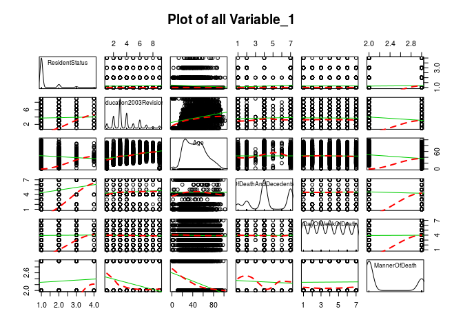

```r
scatterplotMatrix(death[1:6000,c(2,3,5,6,8,10)],
                  spread=FALSE, smoother.args=list(lty=2),
                  main="Plot of all Variable_1")
```

**corealation plot** by method this plot will remove bad correlation .

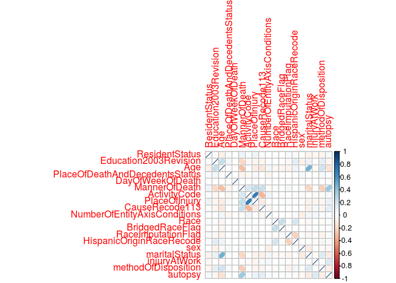

```r
corr=cor(death[,c(2,3,5,6,8,10,13:16,18:26)])
corrplot(corr,method = "ellipse")
```

۲. اثر هر یک از متغیرهای جنسیت، نژاد،آموزش، سن و نحوه تدفین را بر مرگ یا خودکشی ارزیابی کنید.

for each part i first plot a plot to show that feature effect on sucside and then by a t-test i evaluate how much diffrence between sucside and dead is significant . **sex**

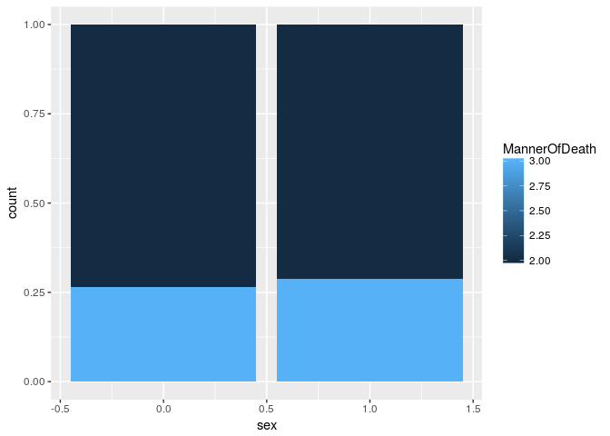

```r
ggplot(death,aes(sex,group=MannerOfDeath,fill=MannerOfDeath))+geom_bar(position = "fill")
```

```r
t.test(filter(death,death$sex==0)$MannerOfDeath,filter(death,death$sex==1)$MannerOfDeath)
```

```
##
##  Welch Two Sample t-test
##
## data:  filter(death, death$sex == 0)$MannerOfDeath and filter(death, death$sex == 1)$MannerOfDeath
## t = -5.1397, df = 19870, p-value = 2.777e-07
## alternative hypothesis: true difference in means is not equal to 0
## 95 percent confidence interval:
##  -0.03250596 -0.01455779
## sample estimates:
## mean of x mean of y
##  2.263979  2.287511
```

**race**

[figure not shown]

```r
death %>% select(MannerOfDeath,Race) %>% merge(.,race)->death_race
ggplot(death_race,aes(Description,group=MannerOfDeath,fill=MannerOfDeath))+
  geom_bar(position = "fill")+theme(axis.text.x  = element_text(angle=90, vjust=0.5,hjust=0))
```

**education**

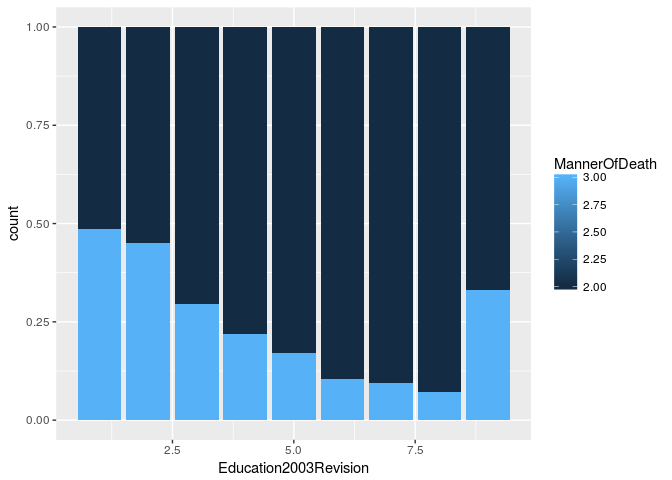

```r
ggplot(death,aes(Education2003Revision,group=MannerOfDeath,fill=MannerOfDeath))+
  geom_bar(position = "fill")
```

```r
t.test(filter(death,death$MannerOfDeath==2&Education2003Revision!=9)$Education2003Revision,filter(death,death$MannerOfDeath==3&Education2003Revision!=9)$Education2003Revision)
```

```
##
##  Welch Two Sample t-test
##
## data:  filter(death, death$MannerOfDeath == 2 & Education2003Revision !=  and filter(death, death$MannerOfDeath == 3 & Education2003Revision !=     9)$Education2003Revision and     9)$Education2003Revision
## t = 64.47, df = 34242, p-value < 2.2e-16
## alternative hypothesis: true difference in means is not equal to 0
## 95 percent confidence interval:
##  0.8086609 0.8593726
## sample estimates:
## mean of x mean of y
##  3.760178  2.926161
```

**AGE**

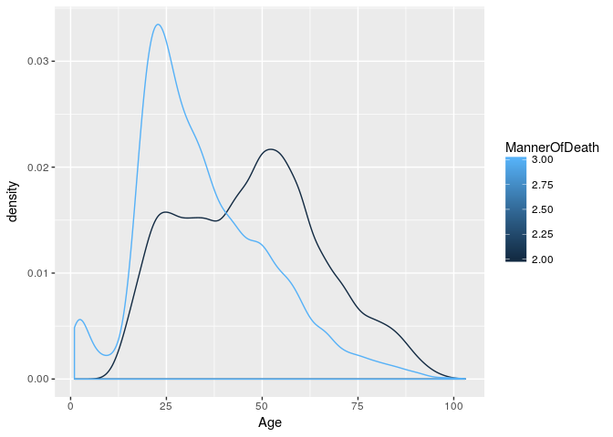

```r
ggplot(death,aes(Age,group=MannerOfDeath,color=MannerOfDeath))+geom_density()
```

```r
t.test(filter(death,death$MannerOfDeath==2)$Age,filter(death,death$MannerOfDeath==3)$Age)
```

```
##
##  Welch Two Sample t-test
##
## data:  filter(death, death$MannerOfDeath == 2)$Age and filter(death, death$MannerOfDeath == 3)$Age
## t = 76.821, df = 30373, p-value < 2.2e-16
## alternative hypothesis: true difference in means is not equal to 0
## 95 percent confidence interval:
##  12.38901 13.03776
## sample estimates:
## mean of x mean of y
##  47.42249  34.70911
```

**MethodOfDisposition**

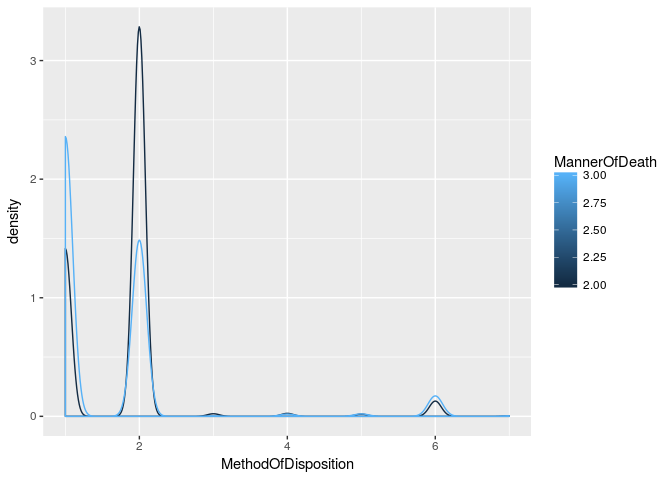

```r
ggplot(death,aes(MethodOfDisposition,group=MannerOfDeath,color=MannerOfDeath))+geom_density()
```

```r
t.test(as.numeric(filter(death,death$MannerOfDeath==2)$MethodOfDisposition),as.numeric(filter(death,death$MannerOfDeath==3)$MethodOfDisposition))
```

```
##
##  Welch Two Sample t-test
##
## data:  as.numeric(filter(death, death$MannerOfDeath == 2)$MethodOfDisposition) and as.numeric(filter(death, death$MannerOfDeath == 3)$MethodOfDisposition)
## t = 22.932, df = 23406, p-value < 2.2e-16
## alternative hypothesis: true difference in means is not equal to 0
## 95 percent confidence interval:
##  0.2080682 0.2469600
## sample estimates:
## mean of x mean of y
##  1.847806  1.620292
```

۳. با استفاده از مدل رگرسیون لاجستیک یک مدل به داده ها برازش دهید و سپس آن را نقص یابی کنید.

```r
death=mutate(death,suicide=(MannerOfDeath==2)*1)
mylogit = glm(suicide ~ Age+ResidentStatus+Education2003Revision+sex+
                maritalStatus+injuryAtWork+methodOfDisposition+ActivityCode+
                PlaceOfInjury+CauseRecode113+Race+BridgedRaceFlag+
                RaceImputationFlag+HispanicOriginRaceRecode+autopsy,
                data= death, family = binomial(link = 'logit'))
death = death %>% mutate(preds = predict(mylogit, type = 'response'))
```

*summery of model*

```r
summary(mylogit)
```

```
##
## Call:
## glm(formula = suicide ~ Age + ResidentStatus + Education2003Revision +
##     sex + maritalStatus + injuryAtWork + methodOfDisposition +
##     ActivityCode + PlaceOfInjury + CauseRecode113 + Race + BridgedRaceFlag +
##     RaceImputationFlag + HispanicOriginRaceRecode + autopsy,
##     family = binomial(link = "logit"), data = death)
##
## Deviance Residuals:
##     Min       1Q   Median       3Q      Max
## -8.4904  -0.3776   0.2205   0.4353   8.4904
##
## Coefficients:
##                            Estimate Std. Error z value Pr(>|z|)
## (Intercept)               1.264e+02  1.349e+00  93.664  < 2e-16 ***
## Age                       1.502e-02  9.655e-04  15.558  < 2e-16 ***
## ResidentStatus            6.046e-02  2.384e-02   2.536   0.0112 *
## Education2003Revision     1.773e-01  9.107e-03  19.468  < 2e-16 ***
## sex                      -5.387e-02  3.332e-02  -1.617   0.1059
## maritalStatus             1.231e-01  1.471e-02   8.368  < 2e-16 ***
## injuryAtWork              1.085e-01  2.090e-02   5.192 2.08e-07 ***
## methodOfDisposition       5.656e-01  2.352e-02  24.048  < 2e-16 ***
## ActivityCode             -2.235e-01  5.881e-03 -38.001  < 2e-16 ***
## PlaceOfInjury            -1.326e-01  1.817e-03 -72.978  < 2e-16 ***
## CauseRecode113           -9.635e-01  1.047e-02 -92.019  < 2e-16 ***
## Race                      5.126e-03  2.101e-03   2.440   0.0147 *
## BridgedRaceFlag           7.952e-02  1.290e-01   0.617   0.5375
## RaceImputationFlag       -2.535e-01  5.172e-02  -4.901 9.55e-07 ***
## HispanicOriginRaceRecode -7.706e-02  8.567e-03  -8.995  < 2e-16 ***
## autopsy                  -1.791e+00  4.355e-02 -41.117  < 2e-16 ***
## ---
## Signif. codes:  0 '***' 0.001 '**' 0.01 '*' 0.05 '.' 0.1 ' ' 1
##
## (Dispersion parameter for binomial family taken to be 1)
##
##     Null deviance: 64702  on 54361  degrees of freedom
## Residual deviance: 32185  on 54346  degrees of freedom
## AIC: 32217
##
## Number of Fisher Scoring iterations: 25
```

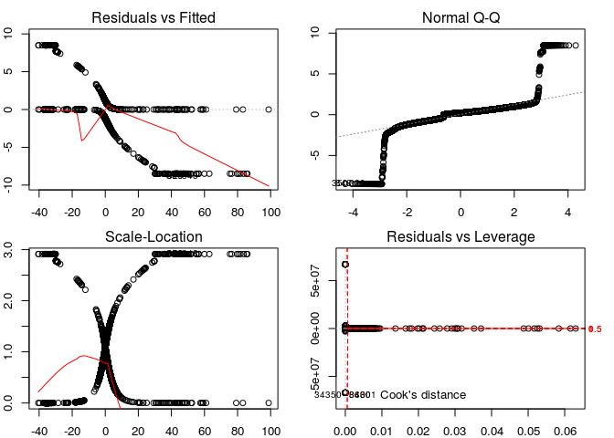

```r
# Change the layout to 2x2 to accommodate all plots
par(mfrow=c(2,2))
par(mar = rep(2, 4))

# Diagnostic Plots
plot(mylogit)
```

۴. با استفاده از سه نمودار خروجی مدل را نسبت به داده واقعی ارزیابی کنید.

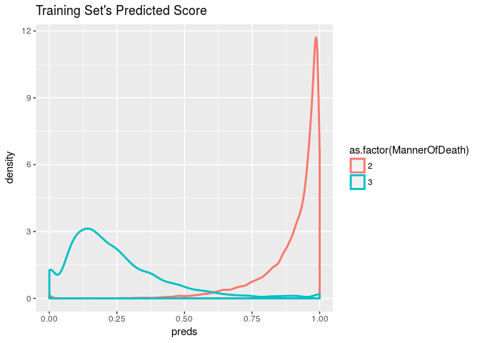

```r
ggplot( death , aes( preds , color = as.factor(MannerOfDeath))) +
geom_density( size = 1 ) +
ggtitle( "Training Set's Predicted Score" )
```

as it can be seen glm model performs good on this data .

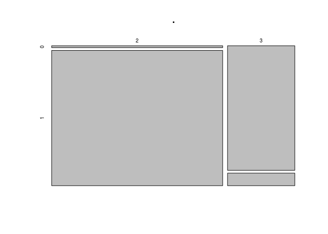

```r
table(death$MannerOfDeath,ifelse(fitted(mylogit)>0.5,1,0)) %>% plot()
```

۵. ابتدا ۲۰ درصد داده را به صورت تصادفی به عنوان تست در نظر بگیرید. مدل را با استفاده از ۸۰ درصد باقی مانده برازش دهید. با استفاده از پارامتر قطع ۰.۵ نتایج را برای داده تست پیش بینی کنید. سپس کمیت های زیر را محاسبه کنید.

- P: positive samples
- N: negative samples
- TP: true positive TP (eqv. with hit)
- TN: true negative (eqv. with correct rejection)
- FP: false positive (eqv. with false alarm, Type I error)
- FN: false negative (eqv. with miss, Type II error)
- Accuracy (ACC) ACC = (TP+TN)/(P+T)
- False positive rate (FPR): 1- TN/N
- True positive rate (TPR): TP/P

مشابه آنچه در کلاس گفته شد نمایشی از چهار کمیت TN, TP,FP,FN به همراه داده ها رسم نمایید.

```r
library(caTools)
set.seed(8)
death = na.omit(death)
death=mutate(death,suicide=(MannerOfDeath==2)*1)
split <- sample.split(death, SplitRatio = 0.8)
#get training and test data


train <- subset(death, split == TRUE)
test <- subset(death, split == FALSE)

mylogit_train = glm(suicide ~ Age+ResidentStatus+Education2003Revision+sex+
                maritalStatus+injuryAtWork+methodOfDisposition+ActivityCode+
                PlaceOfInjury+CauseRecode113+Race+BridgedRaceFlag+
                RaceImputationFlag+HispanicOriginRaceRecode+autopsy,
                data= train, family = binomial(link = 'logit'))
summary(mylogit_train)
```

```
##
## Call:
## glm(formula = suicide ~ Age + ResidentStatus + Education2003Revision +
##     sex + maritalStatus + injuryAtWork + methodOfDisposition +
##     ActivityCode + PlaceOfInjury + CauseRecode113 + Race + BridgedRaceFlag +
##     RaceImputationFlag + HispanicOriginRaceRecode + autopsy,
##     family = binomial(link = "logit"), data = train)
##
## Deviance Residuals:
##    Min      1Q  Median      3Q     Max
##  -8.49    0.00    0.00    0.00    8.49
##
## Coefficients:
##                            Estimate Std. Error    z value Pr(>|z|)
## (Intercept)               4.548e+16  1.139e+07  3.993e+09   <2e-16 ***
## Age                       4.673e+12  2.046e+04  2.284e+08   <2e-16 ***
## ResidentStatus            3.891e+13  6.008e+05  6.476e+07   <2e-16 ***
## Education2003Revision     3.978e+13  1.979e+05  2.010e+08   <2e-16 ***
## sex                      -1.381e+13  7.926e+05 -1.742e+07   <2e-16 ***
## maritalStatus             1.075e+13  3.261e+05  3.297e+07   <2e-16 ***
## injuryAtWork             -6.280e+13  5.092e+05 -1.233e+08   <2e-16 ***
## methodOfDisposition       9.518e+13  5.770e+05  1.650e+08   <2e-16 ***
## ActivityCode             -5.472e+13  3.973e+04 -1.377e+09   <2e-16 ***
## PlaceOfInjury            -4.709e+13  3.063e+04 -1.537e+09   <2e-16 ***
## CauseRecode113           -3.391e+14  8.723e+04 -3.887e+09   <2e-16 ***
## Race                      4.938e+12  5.285e+04  9.345e+07   <2e-16 ***
## BridgedRaceFlag          -3.281e+13  3.207e+06 -1.023e+07   <2e-16 ***
## RaceImputationFlag       -1.182e+14  1.331e+06 -8.886e+07   <2e-16 ***
## HispanicOriginRaceRecode -4.083e+13  2.256e+05 -1.810e+08   <2e-16 ***
## autopsy                  -8.816e+14  6.467e+05 -1.363e+09   <2e-16 ***
## ---
## Signif. codes:  0 '***' 0.001 '**' 0.01 '*' 0.05 '.' 0.1 ' ' 1
##
## (Dispersion parameter for binomial family taken to be 1)
##
##     Null deviance: 50817  on 42711  degrees of freedom
## Residual deviance: 94939  on 42696  degrees of freedom
## AIC: 94971
##
## Number of Fisher Scoring iterations: 25
```

```r
train$prediction = predict( mylogit_train, newdata = train, type = "response" )
test$prediction = predict( mylogit_train, newdata = test, type = "response" )

#confusion matrix
table(train$suicide, train$prediction > 0.5)
```

```
##
##     FALSE  TRUE
##   0 10851  1196
##   1   121 30544
```

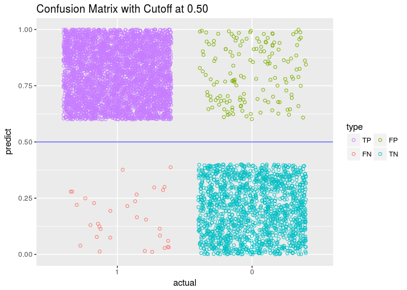

```r
cm_info = ConfusionMatrixInfo( data = test, predict = "prediction",
                                actual = "suicide", cutoff =0.5)
cm_info$plot
```

۶. نمودار صحت مدل (accuracy) را بر حسب مقادیر مختلف قطع برای داده تست رسم نمایید. کدام پارامتر قطع بالاترین صحت را در پیش بینی داراست؟

```r
accuracy_info = AccuracyCutoffInfo( train = train, test = test,
                                     predict = "prediction", actual = "suicide" )
```

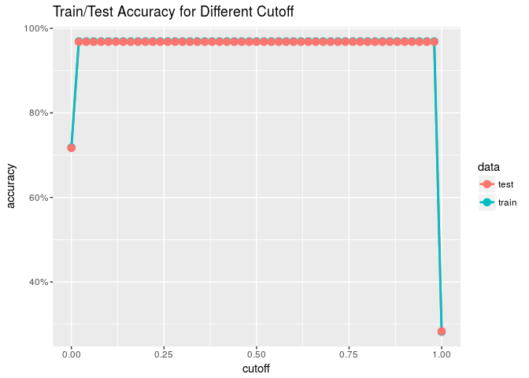

```r
accuracy_info$plot
```

۷. نمودار ROC را برای داده های قسمت قبل رسم نمایید. همچنین نقطه مربوط به بهترین پارامتر قطع را مشخص نمایید.

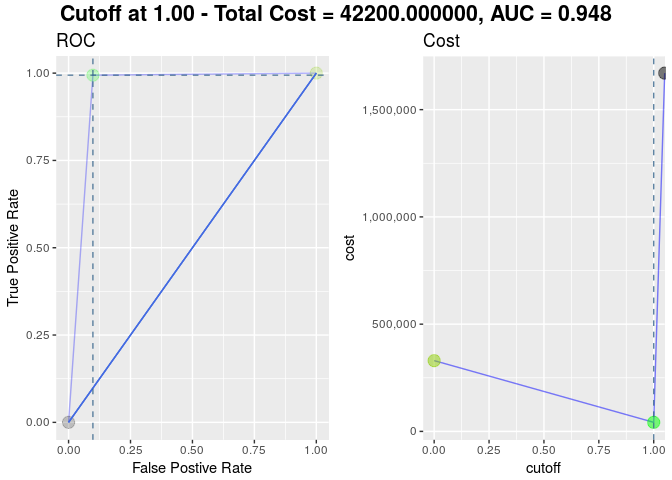

```r
cost_fp = 100;cost_fn = 200
roc_info = ROCInfo( data = cm_info$data, predict = "predict",
                     actual = "actual", cost.fp = cost_fp, cost.fn = cost_fn )
grid.draw(roc_info$plot)
```

۸. با قرار دادن کمیت nfolds = 5 و با استفاده از H20 مدل مساله را بسازید و نتیجه حاصل را ارزیابی کنید.

```r
library(h2o)
h2o.init()
```

```
##  Connection successful!
##
## R is connected to the H2O cluster:
##     H2O cluster uptime:         2 hours 13 minutes
##     H2O cluster timezone:       Asia/Tehran
##     H2O data parsing timezone:  UTC
##     H2O cluster version:        3.19.0.4257
##     H2O cluster version age:    20 days
##     H2O cluster name:           H2O_started_from_R_saleh_hhe287
##     H2O cluster total nodes:    1
##     H2O cluster total memory:   2.41 GB
##     H2O cluster total cores:    4
##     H2O cluster allowed cores:  4
##     H2O cluster healthy:        TRUE
##     H2O Connection ip:          localhost
##     H2O Connection port:        54321
##     H2O Connection proxy:       NA
##     H2O Internal Security:      FALSE
##     H2O API Extensions:         XGBoost, Algos, AutoML, Core V3, Core V4
##     R Version:                  R version 3.4.3 (2017-11-30)
```

```r
hdeath = as.h2o(death)
chglm = h2o.glm(y = "suicide", x= c('Age','ResidentStatus','Education2003Revision','sex',
                'maritalStatus','injuryAtWork','methodOfDisposition','ActivityCode'
                ,'PlaceOfInjury','CauseRecode113','Race','BridgedRaceFlag'
                ,'RaceImputationFlag','HispanicOriginRaceRecode','autopsy'),
               training_frame = hdeath, family="binomial",nfolds = 5)
chglm
```

```
## Model Details:
## ==============
##
## H2OBinomialModel: glm
## Model ID:  GLM_model_R_1524945041084_55
## GLM Model: summary
##     family  link                                regularization
## 1 binomial logit Elastic Net (alpha = 0.5, lambda = 3.323E-4 )
##   number_of_predictors_total number_of_active_predictors
## 1                         15                          15
##   number_of_iterations training_frame
## 1                    9          death
##
## Coefficients: glm coefficients
##                       names coefficients standardized_coefficients
## 1                 Intercept    46.744242                  1.112595
## 2            ResidentStatus    -0.028095                 -0.015328
## 3     Education2003Revision     0.162955                  0.278153
## 4                       Age     0.014818                  0.280123
## 5              ActivityCode    -0.051681                 -0.632152
## 6             PlaceOfInjury    -0.044120                 -0.666094
## 7            CauseRecode113    -0.356863                 -1.494684
## 8                      Race     0.003719                  0.024075
## 9           BridgedRaceFlag     0.088668                  0.009249
## 10       RaceImputationFlag    -0.264943                 -0.066750
## 11 HispanicOriginRaceRecode    -0.071731                 -0.108835
## 12                      sex    -0.039142                 -0.016260
## 13            maritalStatus     0.131181                  0.149973
## 14             injuryAtWork     0.179104                  0.116160
## 15      methodOfDisposition     0.561414                  0.325470
## 16                  autopsy    -1.409677                 -0.734650
##
## H2OBinomialMetrics: glm
## ** Reported on training data. **
##
## MSE:  0.09107092
## RMSE:  0.3017796
## LogLoss:  0.3595972
## Mean Per-Class Error:  0.1214955
## AUC:  0.9505165
```

[output cut: 74 more lines]

```
## ---
##                         mean           sd cv_1_valid cv_2_valid cv_3_valid
## precision          0.9237702 0.0035097792  0.9278452 0.91438526  0.9238479
## r2                 0.5520934  0.004495412 0.56346464  0.5538253  0.5488308
## recall             0.9539301 0.0029001897  0.9542648  0.9590185   0.952369
## residual_deviance   8346.401    685.46405  10268.934  7882.1787  7688.8374
## rmse              0.30120945 0.0022556568 0.29600453  0.3036903 0.30053806
## specificity        0.7999936 0.0072083743  0.8072644  0.7822096  0.7949309
##                   cv_4_valid cv_5_valid
## precision          0.9248358   0.927937
## r2                0.54485804  0.5494881
## recall            0.94708925 0.95690876
## residual_deviance    8076.39   7815.666
## rmse              0.30529657 0.30051777
## specificity        0.8091113  0.8064516
```

۹. آیا ما میتوانیم سرویسی به قضات ارایه کنیم تا با استفاده از اطلاعات مرگ بتوانند موارد مشکوک به قتل را از خودکشی تفکیک دهند؟

پاسخ : با توجه به مدلی که بدست آورده ایم و بررسی های انجام شده روی دقت آن به نظر میرسد می توان از مدل برای کمک به قضات در بررسی مسایل جنایی کمک کرد .